# LogisticRegressionExample

Longstreth, Michael

June 23, 2019

# 1 Objective

Use the [National Health and Nutrition Examination Survey](https://en.wikipedia.org/wiki/National_Health_and_Nutrition_Examination_Survey) dataset **nhanes** (see below) for this problem.

- Use the nhanes data to predict the outcome **DIQ010** indicating diabetes diagnosis (yes/no) from the above dataset.
- Prepare your dataset (e.g., to avoid overfitting)
- Fit you logistic regression, random forest, and gbm models to predict DIQ010
- Tune your models to optimize performance
- Show and *explain* your results, use plots where appropriate
- Evaluate comparative model performance
- State your conclusions

```r
#  Do not change the code in this chunk!
nhanes <- read_csv('nhanes.csv')
```

# 2 Examine raw data from data set.

```r
head(nhanes, n = 10)
```

```
# A tibble: 10 x 36
   INDFMPIR RIAGENDR RIDAGEYR RIDRETH1 DR1_300 DR1_320Z DR1TALCO DR1TCAFF
      <dbl> <chr>       <dbl> <chr>    <chr>      <dbl>    <dbl>    <dbl>
 1     4.65 Female         44 Non-His~ Much l~     193.      0         13
 2     5    Male           70 Non-His~ Usual       830.     40.8      260
 3     5    Female         16 Non-His~ Much l~     118.      0         71
 4     5    Male           19 Non-His~ Usual      1539.      0          0
 5     0.46 Male           21 Other H~ Much l~    2577.     36.3       10
 6     1.06 Female         16 Non-His~ Usual         0       0        121
 7     1.22 Male           79 Non-His~ Usual      2281.     54.3       95
 8     3.03 Female         59 Non-His~ Much l~     974       0        249
 9     1.76 Female         27 Mexican~ Usual       622.      0         39
10     1.03 Female         44 Other R~ Usual      1421.      0        218
# ... with 28 more variables: DR1TCARB <dbl>, DR1TCHOL <dbl>,
#   DR1TFIBE <dbl>, DR1TKCAL <dbl>, DR1TPROT <dbl>, DR1TSFAT <dbl>,
#   DR1TSODI <dbl>, DR1TSUGR <dbl>, DR1TTFAT <dbl>, BMXBMI <dbl>,
#   BPXDI1 <dbl>, BPXPLS <dbl>, BPXSY1 <dbl>, LBDSBUSI <dbl>,
#   LBDSCHSI <dbl>, LBDSCRSI <dbl>, LBDSGLSI <dbl>, LBDSTPSI <dbl>,
#   LBDSTRSI <dbl>, LBDTCSI <dbl>, LBXGH <dbl>, LBXSAPSI <dbl>,
#   LBXSBU <dbl>, LBXSNASI <dbl>, LBXSOSSI <dbl>, DIQ010 <chr>,
#   SLQ050 <chr>, WHQ030 <chr>
```

```r
tail(nhanes, n = 10)
```

```
# A tibble: 10 x 36
   INDFMPIR RIAGENDR RIDAGEYR RIDRETH1 DR1_300 DR1_320Z DR1TALCO DR1TCAFF
      <dbl> <chr>       <dbl> <chr>    <chr>      <dbl>    <dbl>    <dbl>
 1     1.76 Female         34 Non-His~ Usual       1575     36         99
 2     5    Female         41 Other R~ Much l~     1200      0        107
 3     2.81 Male           34 Non-His~ Usual        900      0         61
 4     0.49 Male           53 Mexican~ Usual        507      0         32
 5     0.4  Female         16 Other H~ Much m~        0      0          7
 6     0.97 Female         69 Mexican~ Usual       1125      0        288
 7     5    Male           32 Other H~ Much m~        0     18.7      112
 8     1.59 Male           25 Other R~ Usual          0      0         65
 9     1.43 Female         76 Non-His~ Usual       1014      0         51
10     3.54 Female         24 Non-His~ Usual        987     31.8      192
# ... with 28 more variables: DR1TCARB <dbl>, DR1TCHOL <dbl>,
#   DR1TFIBE <dbl>, DR1TKCAL <dbl>, DR1TPROT <dbl>, DR1TSFAT <dbl>,
#   DR1TSODI <dbl>, DR1TSUGR <dbl>, DR1TTFAT <dbl>, BMXBMI <dbl>,
#   BPXDI1 <dbl>, BPXPLS <dbl>, BPXSY1 <dbl>, LBDSBUSI <dbl>,
#   LBDSCHSI <dbl>, LBDSCRSI <dbl>, LBDSGLSI <dbl>, LBDSTPSI <dbl>,
#   LBDSTRSI <dbl>, LBDTCSI <dbl>, LBXGH <dbl>, LBXSAPSI <dbl>,
#   LBXSBU <dbl>, LBXSNASI <dbl>, LBXSOSSI <dbl>, DIQ010 <chr>,
#   SLQ050 <chr>, WHQ030 <chr>
```

```r
dim(nhanes)
```

```
[1] 26193    36
```

```r
glimpse(nhanes)
```

```
Observations: 26,193
Variables: 36
$ INDFMPIR <dbl> 4.65, 5.00, 5.00, 5.00, 0.46, 1.06, 1.22, 3.03, 1.76,...
$ RIAGENDR <chr> "Female", "Male", "Female", "Male", "Male", "Female",...
$ RIDAGEYR <dbl> 44, 70, 16, 19, 21, 16, 79, 59, 27, 44, 62, 38, 43, 7...
$ RIDRETH1 <chr> "Non-Hispanic Black", "Non-Hispanic White", "Non-Hisp...
$ DR1_300  <chr> "Much less than usual", "Usual", "Much less than usua...
$ DR1_320Z <dbl> 192.56, 829.50, 118.50, 1539.20, 2577.38, 0.00, 2281....
$ DR1TALCO <dbl> 0.0, 40.8, 0.0, 0.0, 36.3, 0.0, 54.3, 0.0, 0.0, 0.0, ...
$ DR1TCAFF <dbl> 13, 260, 71, 0, 10, 121, 95, 249, 39, 218, 203, 132, ...
$ DR1TCARB <dbl> 233.73, 269.93, 238.62, 243.56, 243.38, 275.62, 294.9...
$ DR1TCHOL <dbl> 48, 138, 132, 359, 80, 189, 98, 79, 1103, 36, 139, 51...
$ DR1TFIBE <dbl> 6.4, 20.3, 8.3, 14.3, 10.2, 9.7, 30.3, 8.7, 15.2, 66....
$ DR1TKCAL <dbl> 1458, 2168, 1688, 2232, 2083, 2322, 2134, 1722, 2223,...
$ DR1TPROT <dbl> 27.43, 75.81, 45.92, 95.17, 51.05, 84.28, 73.87, 40.2...
```

[output cut: 23 more lines]

# 3 Convert character strings to factors.

```r
nhanes_factors <- c(2, 4, 5, 34, 35, 36)
nhanes[,nhanes_factors] <- map(nhanes[,nhanes_factors],
                               as.factor)
```

# 4 View balance of categorical variables in dataset.

```r
CrossTable(nhanes$RIAGENDR)
```

```
   Cell Contents
|-------------------------|
|                       N |
|         N / Table Total |
|-------------------------|


Total Observations in Table:  26193


          |    Female |      Male |
          |-----------|-----------|
          |     13261 |     12932 |
          |     0.506 |     0.494 |
          |-----------|-----------|
```

```r
summary(nhanes$RIDRETH1)
```

```
                   Mexican American                  Non-Hispanic Black
                               4540                                5549
                 Non-Hispanic White                      Other Hispanic
                              11172                                2458
Other Race - Including Multi-Racial
                               2474
```

```r
CrossTable(nhanes$DR1_300)
```

```
   Cell Contents
|-------------------------|
|                       N |
|         N / Table Total |
|-------------------------|


Total Observations in Table:  26193


                     | Much less than usual | Much more than usual |                Usual |
                     |----------------------|----------------------|----------------------|
                     |                 5166 |                 2318 |                18709 |
                     |                0.197 |                0.088 |                0.714 |
                     |----------------------|----------------------|----------------------|
```

```r
CrossTable(nhanes$DIQ010)
```

```
   Cell Contents
|-------------------------|
|                       N |
|         N / Table Total |
|-------------------------|


Total Observations in Table:  26193


          |        No |       Yes |
          |-----------|-----------|
          |     23010 |      3183 |
          |     0.878 |     0.122 |
          |-----------|-----------|
```

```r
CrossTable(nhanes$SLQ050)
```

```
   Cell Contents
|-------------------------|
|                       N |
|         N / Table Total |
|-------------------------|


Total Observations in Table:  26193


          |        No |       Yes |
          |-----------|-----------|
          |     20071 |      6122 |
          |     0.766 |     0.234 |
          |-----------|-----------|
```

```r
CrossTable(nhanes$WHQ030)
```

```
   Cell Contents
|-------------------------|
|                       N |
|         N / Table Total |
|-------------------------|


Total Observations in Table:  26193


                        | About the right weight? |             Overweight, |         Underweight, or |
                        |-------------------------|-------------------------|-------------------------|
                        |                   11170 |                   13619 |                    1404 |
                        |                   0.426 |                   0.520 |                   0.054 |
                        |-------------------------|-------------------------|-------------------------|
```

# 5 Check for and remove missing value.

```r
sapply(nhanes, function(x) sum(is.na(x)))
```

```
INDFMPIR RIAGENDR RIDAGEYR RIDRETH1  DR1_300 DR1_320Z DR1TALCO DR1TCAFF
       0        0        0        0        0        0        0        0
DR1TCARB DR1TCHOL DR1TFIBE DR1TKCAL DR1TPROT DR1TSFAT DR1TSODI DR1TSUGR
       0        0        0        0        0        0        0        0
DR1TTFAT   BMXBMI   BPXDI1   BPXPLS   BPXSY1 LBDSBUSI LBDSCHSI LBDSCRSI
       0        0        0        0        0        0        0        0
LBDSGLSI LBDSTPSI LBDSTRSI  LBDTCSI    LBXGH LBXSAPSI   LBXSBU LBXSNASI
       0        0        0        0        0        0        0        0
LBXSOSSI   DIQ010   SLQ050   WHQ030
       0        0        0        0
```

```r
library(dplyr)
nhanes <- nhanes %>% drop_na()
```

# 6 Create train/test sets and Formula for models.

```r
library(caret)
library(broom)
set.seed(123)
assignment1 <- sample(1:2,
                      size = nrow(nhanes),
                      prob = c(.8, .2),
                      replace = TRUE)
nhanes_train <- nhanes[assignment1 == 1,]
nhanes_test <- nhanes[assignment1 == 2,]
nhanes_fm <- formula(DIQ010 ~ .)
```

# 7 Create first tree-model (“RPart”)

We will use AUC as to evaluate model performance.

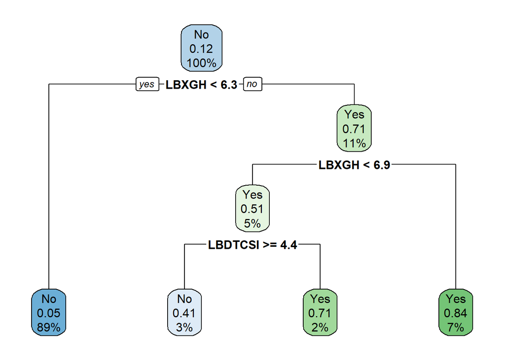

```r
rpart_hanes_model <- rpart(formula = nhanes_fm,
                           data = nhanes_train,
                           method = "class")
rpart.plot(rpart_hanes_model)
```

```r
print(rpart_hanes_model)
```

```
n= 20969

node), split, n, loss, yval, (yprob)
      * denotes terminal node

 1) root 20969 2565 No (0.87767657 0.12232343)
   2) LBXGH< 6.25 18577  878 No (0.95273726 0.04726274) *
   3) LBXGH>=6.25 2392  705 Yes (0.29473244 0.70526756)
     6) LBXGH< 6.85 984  479 Yes (0.48678862 0.51321138)
      12) LBDTCSI>=4.355 641  260 No (0.59438378 0.40561622) *
      13) LBDTCSI< 4.355 343   98 Yes (0.28571429 0.71428571) *
     7) LBXGH>=6.85 1408  226 Yes (0.16051136 0.83948864) *
```

```r
rpart_hanes_model_prediction_cl <- predict(object = rpart_hanes_model,
                                        newdata = nhanes_test,
                                        type = "class")
rpart_hanes_model_prediction_prob <- predict(object = rpart_hanes_model,
                                        newdata = nhanes_test,
                                        type = "prob")
confusionMatrix(data = rpart_hanes_model_prediction_cl,
                reference = nhanes_test$DIQ010)
```

```
Confusion Matrix and Statistics

          Reference
Prediction   No  Yes
       No  4527  269
       Yes   79  349

               Accuracy : 0.9334
                 95% CI : (0.9263, 0.94)
    No Information Rate : 0.8817
    P-Value [Acc > NIR] : < 2.2e-16

                  Kappa : 0.6316

 Mcnemar's Test P-Value : < 2.2e-16

            Sensitivity : 0.9828
            Specificity : 0.5647
         Pos Pred Value : 0.9439
         Neg Pred Value : 0.8154
             Prevalence : 0.8817
         Detection Rate : 0.8666
   Detection Prevalence : 0.9181
      Balanced Accuracy : 0.7738

       'Positive' Class : No
```

```r
rpart_auc<- auc(actual = ifelse(nhanes_test$DIQ010 == "Yes", 1, 0),
                predicted = rpart_hanes_model_prediction_prob[,"Yes"])
class_model_performance <- list()
class_model_performance[1] <- rpart_auc
names(class_model_performance) <- c("rpart_auc")
class_model_performance
```

```
$rpart_auc
[1] 0.8257948
```

# 8 Bootstrap model.

```r
bag_hanes_model <- bagging(formula = nhanes_fm,
                           data = nhanes_train,
                           type = "class",
                           cobb = TRUE)
bag_hanes_model_prediction_cl <- predict(object = bag_hanes_model,
                                         newdata = nhanes_test,
                                         type = "class")
bag_hanes_model_prediction_prob <- predict(object = bag_hanes_model,
                                           newdata = nhanes_test,
                                           type = "prob")
confusionMatrix(data = bag_hanes_model_prediction_cl,
                reference = nhanes_test$DIQ010)
```

```
Confusion Matrix and Statistics

          Reference
Prediction   No  Yes
       No  4490  228
       Yes  116  390

               Accuracy : 0.9342
                 95% CI : (0.9271, 0.9407)
    No Information Rate : 0.8817
    P-Value [Acc > NIR] : < 2.2e-16

                  Kappa : 0.6575

 Mcnemar's Test P-Value : 2.168e-09

            Sensitivity : 0.9748
            Specificity : 0.6311
         Pos Pred Value : 0.9517
         Neg Pred Value : 0.7708
             Prevalence : 0.8817
         Detection Rate : 0.8595
   Detection Prevalence : 0.9031
      Balanced Accuracy : 0.8029

       'Positive' Class : No
```

```r
boot_auc <- auc(actual = ifelse(nhanes_test$DIQ010 == "Yes", 1, 0),
                predicted = bag_hanes_model_prediction_prob[,"Yes"])
class_model_performance[2] <- boot_auc
names(class_model_performance) <- c("rpart_auc",
                                    "boot_auc")
class_model_performance
```

```
$rpart_auc
[1] 0.8257948

$boot_auc
[1] 0.9156974
```

# 9 Random Forest model.

```r
library(randomForest)
rf_hanes_model <- randomForest(formula = nhanes_fm,
                               data = nhanes_train)
rf_err <- rf_hanes_model$err.rate
head(rf_err)
```

```
           OOB         No       Yes
[1,] 0.1280839 0.08175373 0.4791667
[2,] 0.1208409 0.07105641 0.4852071
[3,] 0.1169501 0.06449275 0.4981569
[4,] 0.1147402 0.06273348 0.4920561
[5,] 0.1080909 0.05486480 0.4906725
[6,] 0.1034974 0.05056831 0.4839516
```

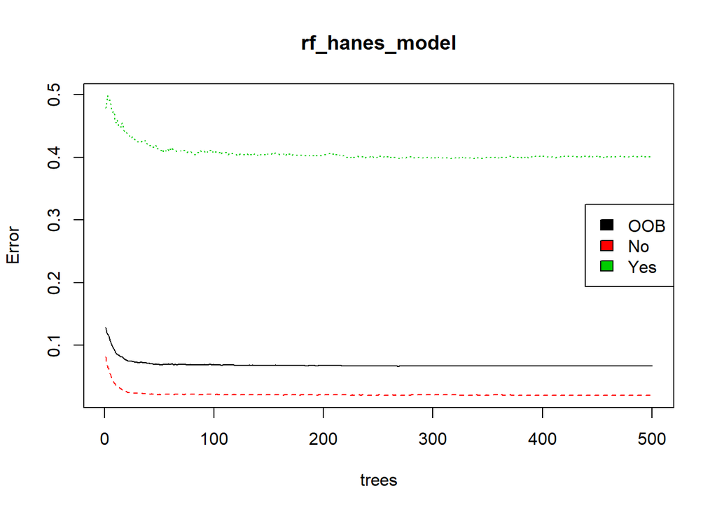

```r
rf_oob_err <- rf_err[500, "OOB"]
plot(rf_hanes_model)
legend(x = "right",
       legend = colnames(rf_err),
       fill = 1:ncol(rf_err))
```

```r
rf_hanes_model_cl <- predict(object = rf_hanes_model,
                             newdata = nhanes_test,
                             type = "class")
rf_hanes_model_prob <- predict(object = rf_hanes_model,
                               newdata = nhanes_test,
                               type = "prob")
rf_cm <- confusionMatrix(data = rf_hanes_model_cl,
                         reference = nhanes_test$DIQ010)
print(rf_cm)
```

```
Confusion Matrix and Statistics

          Reference
Prediction   No  Yes
       No  4520  249
       Yes   86  369

               Accuracy : 0.9359
                 95% CI : (0.9289, 0.9424)
    No Information Rate : 0.8817
    P-Value [Acc > NIR] : < 2.2e-16

                  Kappa : 0.653

 Mcnemar's Test P-Value : < 2.2e-16

            Sensitivity : 0.9813
            Specificity : 0.5971
         Pos Pred Value : 0.9478
         Neg Pred Value : 0.8110
             Prevalence : 0.8817
         Detection Rate : 0.8652
   Detection Prevalence : 0.9129
      Balanced Accuracy : 0.7892

       'Positive' Class : No
```

```r
rf_auc <- auc(actual = ifelse(nhanes_test$DIQ010 == "Yes", 1, 0),
              predicted = rf_hanes_model_prob[,"Yes"])
class_model_performance[3] <- rf_auc
names(class_model_performance) <- c("rpart_auc",
                                    "boot_auc",
                                    "rf_auc")
class_model_performance
```

```
$rpart_auc
[1] 0.8257948

$boot_auc
[1] 0.9156974

$rf_auc
[1] 0.9309872
```

# 10 Tune Random Forest model.

The results of this are an AUC == 1. This leads me to believe that the tuning parameters in the following are not bing applied correctly. I tried various methods to revise this section, but ran out of time.

```r
res <- tuneRF(x = subset(nhanes_test, select = -DIQ010),
              y = nhanes_test$DIQ010,
              ntreeTry = 500,
              doBest = TRUE)
```

```
mtry = 5  OOB error = 6.41%
Searching left ...
mtry = 3    OOB error = 6.7%
-0.04477612 0.05
Searching right ...
mtry = 10   OOB error = 6.37%
0.005970149 0.05
```

[figure not shown]

```r
print(res)
```

```
Call:
 randomForest(x = x, y = y, mtry = res[which.min(res[, 2]), 1])
               Type of random forest: classification
                     Number of trees: 500
No. of variables tried at each split: 10

        OOB estimate of  error rate: 6.22%
Confusion matrix:
      No Yes class.error
No  4517  89  0.01932262
Yes  236 382  0.38187702
```

```r
rfTune_hanes_model_prob <- predict(object = res,
                                   newdata = nhanes_test,
                                   type = "prob")
rfTune_auc <- auc(actual = ifelse(nhanes_test$DIQ010 == "Yes", 1, 0),
              predicted = rfTune_hanes_model_prob[,"Yes"])
class_model_performance[4] <- rfTune_auc
names(class_model_performance) <- c("rpart_auc",
                                    "boot_auc",
                                    "rf_auc",
                                    "rfTune_auc")
class_model_performance
```

```
$rpart_auc
[1] 0.8257948

$boot_auc
[1] 0.9156974

$rf_auc
[1] 0.9309872

$rfTune_auc
[1] 1
```

# 11 GBM model.

```r
nhanes_train$DIQ010 <- ifelse(nhanes_train$DIQ010 == "yes", 1, 0)
set.seed(43)
gbm_nhanes_model <- gbm(formula = nhanes_fm,
                        distribution = "bernoulli",
                        data = nhanes_train,
                        n.trees = 10000)
gbm_nhanes_model
```

```
gbm(formula = nhanes_fm, distribution = "bernoulli", data = nhanes_train,
    n.trees = 10000)
A gradient boosted model with bernoulli loss function.
10000 iterations were performed.
There were 35 predictors of which 0 had non-zero influence.
```

```r
nhanes_test$DIQ010 <- ifelse(nhanes_test$DIQ010 == "yes", 1, 0)
gbm_pred1 <- predict(object = gbm_nhanes_model,
                     newdata = nhanes_test,
                     n.trees = 10000)
gbm_pred2 <- predict(object = gbm_nhanes_model,
                     newdata = nhanes_test,
                     n.trees = 10000,
                     type = "response")
range(gbm_pred1)
```

```
[1] -Inf -Inf
```

```r
range(gbm_pred2)
```

```
[1] 0 0
```

```r
auc(actual = nhanes_test$DIQ010, predicted = gbm_pred1)
```

```
[1] NaN
```

```r
auc(actual = nhanes_test$DIQ010, predicted = gbm_pred2)
```

```
[1] NaN
```

# 12 Conclusion

From using AUC to evaluate the tree-model performance, the Random Forest model provides the highest AUC and shoul be selected to accurately predict the diagnoses of diabetes on the observation. However, since this is a prediction being used to aid in diagnosis, from evluating the confusion matrixes between the Random Forest and Bootsrapped model, the reduction in False Positives in the Bootstrapped model should be taken into consideration, to reduce the chance of mis diagnosis, even though the AUC is less than the Random Forest model.